# Unsupervised learning: PCA and clustering (lab 7 for BIOS 26122)

Author

Dmitry Kondrashov

## Description

The goal of this assignment is to use methods of unsupervised learning, specifically:

- PCA for dimensionality reduction
- clustering using k-means and hierarchical methods
- clustering using reduced dimensions
- validate clustering and compare different methods

## Part 1: Dimensionality reduction using PCA

## Breast cancer data

The Wisconsin breast cancer data set contains information about different tumor biopsies in the form of 30 features of cell nuclei determined from images. The first two variables are the sample ID and the diagnosis (M = malignant or B = benign). The source and description of the data is here: https://archive-beta.ics.uci.edu/ml/datasets/breast+cancer+wisconsin+diagnostic

```r
wisc_data = read_csv("https://raw.githubusercontent.com/dkon1/intro-ml-bio/main/labs/data/wdbc.csv")
```

```
──────────────────────────────────────────────────────── Delimiter: "," chr
(1): Diagnosis dbl (31): ID, radius1, texture1, perimeter1, area1...6,
smoothness1, compact...
```

1. Clean the data set by filtering out any missing values, selecting out the non-predictor variables and fixing a few variable names that have weird characters (the easiest way to do this is to use the function `clean_names()` from the package `janitor`) and assign this to a new tibble. Assign the `Diagnosis` variable into a separate data frame.

   ```r
   wisc_pred<- wisc_data |>
    dplyr::select(-c(ID, Diagnosis)) |>
    clean_names() |>
    drop_na()

   wisc_diag <- wisc_data |>
    dplyr::select(Diagnosis) |>
    drop_na()
   ```

2. Perform PCA on the raw (unscaled) data and make a Scree plot of the eigenvalues. Plot the data points projected onto the first two principalcomponents colored by their Diagnosis.

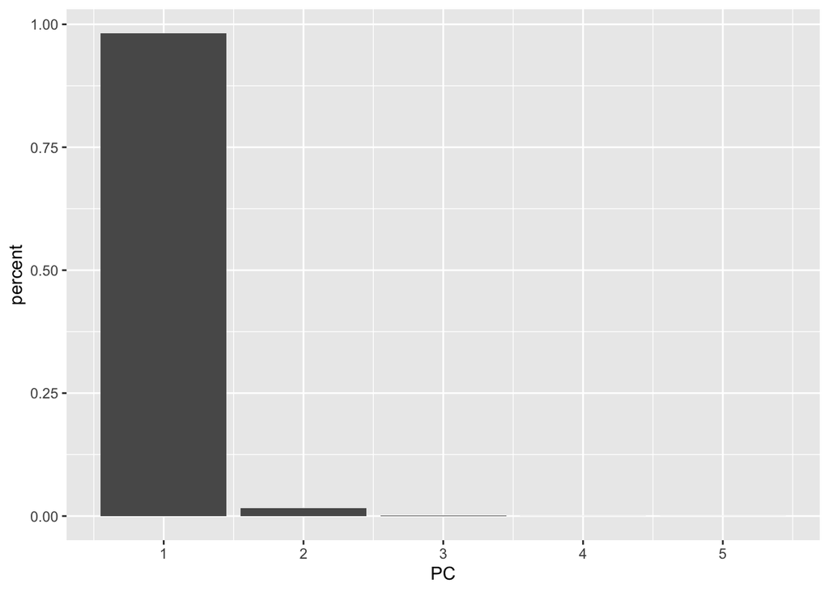

```r
wisc_pca <- wisc_pred  |>
  prcomp(scale = FALSE)

tidy(wisc_pca, matrix = "eigenvalues") |> filter(PC < 6) |>
  ggplot(aes(PC, percent)) +
  geom_col()
```

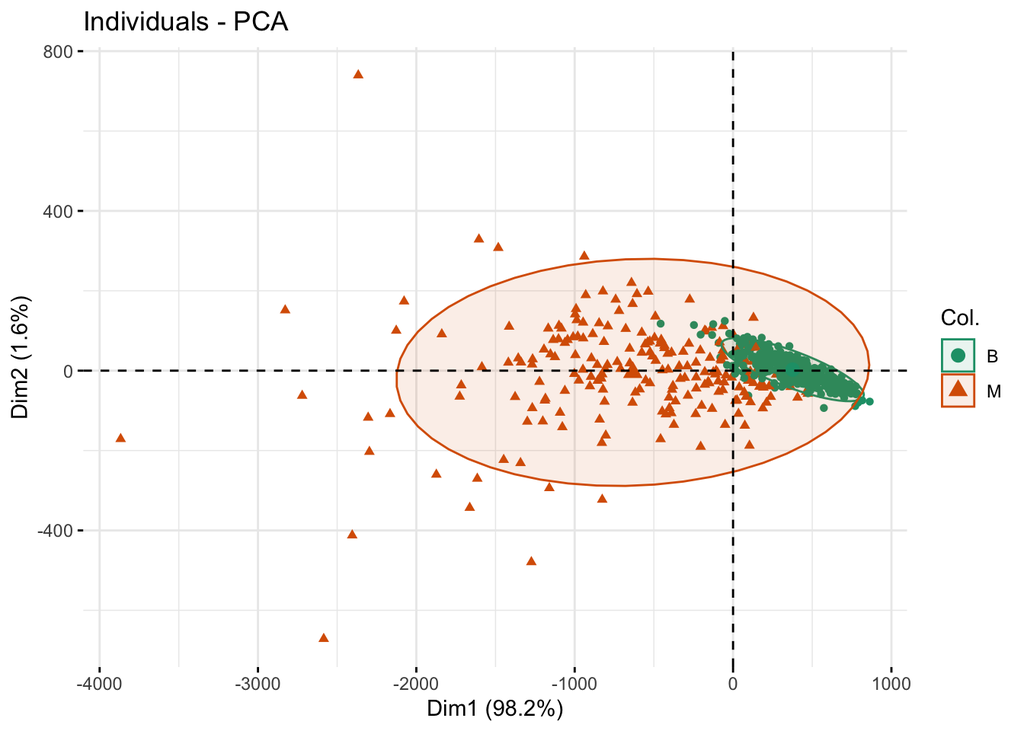

```r
fviz_pca_ind(wisc_pca,
             col.ind = factor(wisc_diag$Diagnosis),
             label = 'none',
             addEllipses=TRUE,
             ellipse.level=0.9,
             palette = "Dark2")
```

3. Perform PCA on the scaled variables and make a Scree plot of the eigenvalues. Plot the data points projected onto the first two principalcomponents colored by their Diagnosis.

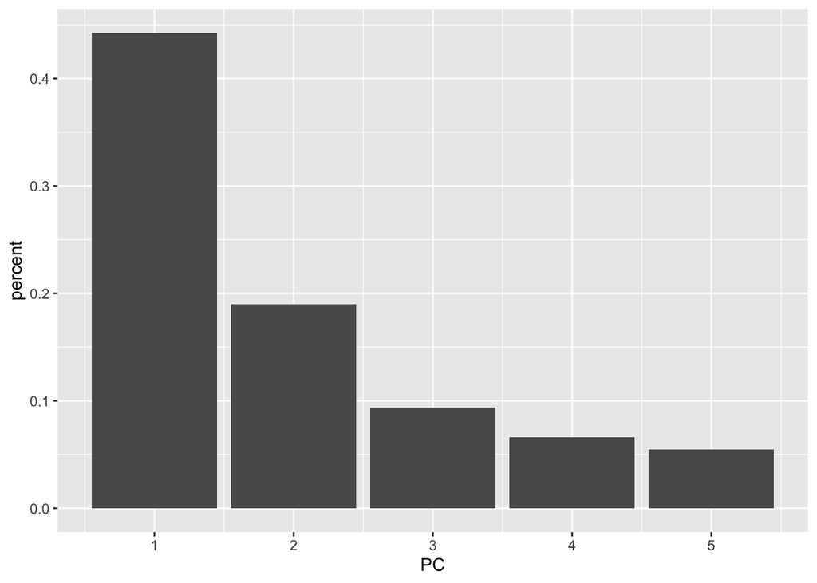

   ```r
   wisc_pca <- wisc_pred  |>
     prcomp(scale = TRUE)

   tidy(wisc_pca, matrix = "eigenvalues") |> filter(PC < 6) |>
     ggplot(aes(PC, percent)) +
     geom_col()
   ```

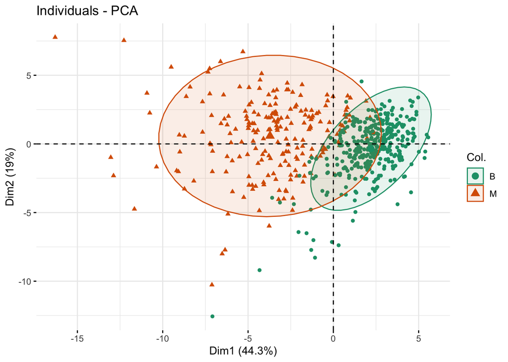

   ```r
   fviz_pca_ind(wisc_pca,
                col.ind = factor(wisc_diag$Diagnosis),
                label = 'none',
                addEllipses=TRUE,
                ellipse.level=0.9,
                palette = "Dark2")
   ```

4. Discuss the PCA results on the scaled and unscaled Wisconsin data by comparing the fraction of variance captured by the first two PCs, and by comparing the plot of the data points projected onto the first two PCs.

### Liver injury data

The following data set contains multiple (376) numeric variables based on assays of different chemical compounds in patients (predictors) and a categorical variable `class` describing the degree of liver damage: ‘none’, ‘mild’, ‘severe’.

```r
data("hepatic_injury_qsar", package = "modeldata")
#glimpse(hepatic_injury_qsar)
```

5. Clean the data to remove any missing values, and select only the **predictor variables that are non-constant (with nonzero variance)** to be used for clustering and assign them to a new tibble. Assign the variable `class` to a separate tibble.

   ```r
   # identify variables with zero variance
   zerovar <- hepatic_injury_qsar |>  dplyr::select(-class) |>
     summarise_all(var) |>
     select_if(function(.) . == 0) |>
     names()

   liver_clean <- hepatic_injury_qsar |> dplyr::select(-class, -all_of(zerovar)) |>
     drop_na()

   liver_class <- hepatic_injury_qsar |>  dplyr::select(class) |>
     drop_na() |>
     mutate(class = factor(class))
   ```

6. Perform PCA on the raw (unscaled) data and make a Scree plot of the eigenvalues. Plot the data points projected onto the first two principal components colored by `class`.

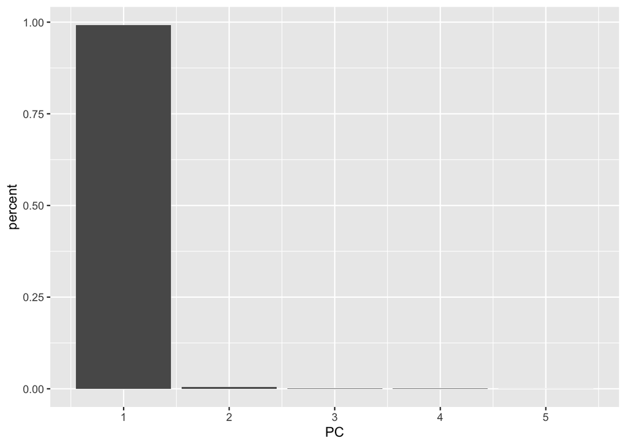

   ```r
   liver_pca <- liver_clean  |>
     prcomp(scale = FALSE)

   tidy(liver_pca, matrix = "eigenvalues") |> filter(PC < 6) |>
     ggplot(aes(PC, percent)) +
     geom_col()
   ```

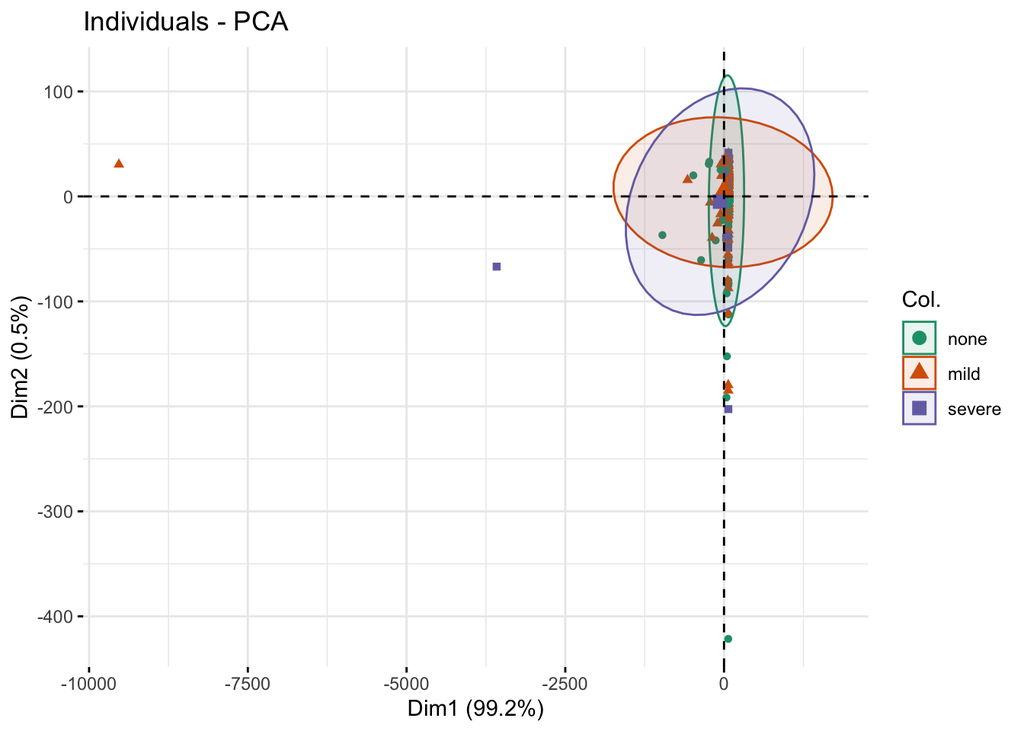

   ```r
   fviz_pca_ind(liver_pca,
                col.ind = factor(liver_class$class),
                label = 'none',
                addEllipses=TRUE,
                ellipse.level=0.9,
                palette = "Dark2")
   ```

7. Perform PCA on the scaled variables and make a Scree plot of the eigenvalues. Plot the data points projected onto the first two principalcom ponents colored by their `class`.

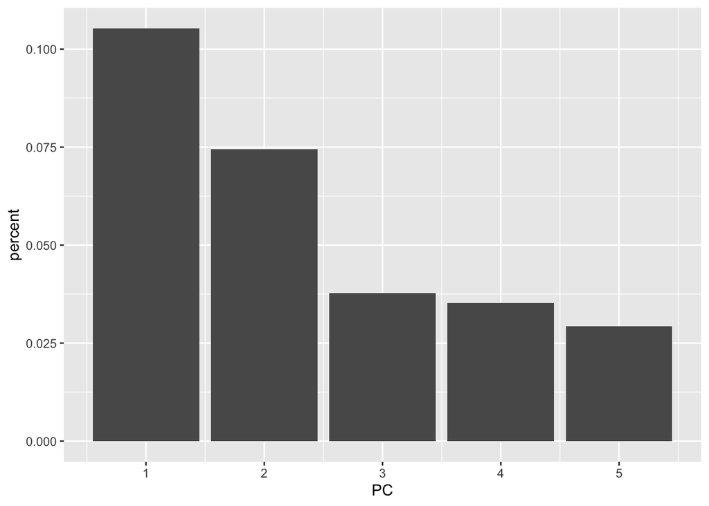

   ```r
   liver_pca <- liver_clean  |>
     prcomp(scale = TRUE)

   tidy(liver_pca, matrix = "eigenvalues") |> filter(PC < 6) |>
     ggplot(aes(PC, percent)) +
     geom_col()
   ```

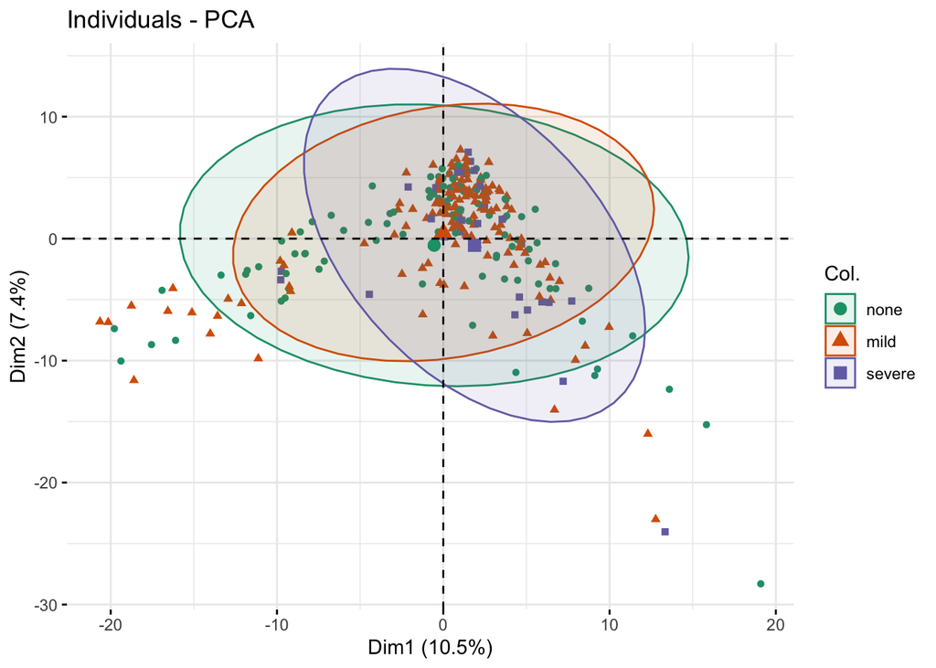

   ```r
   fviz_pca_ind(liver_pca,
                col.ind = factor(liver_class$class),
                label = 'none',
                addEllipses=TRUE,
                ellipse.level=0.9,
                palette = "Dark2")
   ```

8. Discuss the PCA results on the scaled and unscaled liver injury data by comparing the fraction of variance captured by the first two PCs, and by comparing the plot of the data points projected onto the first two PCs.

## Part 2: clustering

### Breast cancer data

1. Perform k-means clustering with k=2 on the Wisconsin data set using all the raw variables. Make a plot of all the data points colored by their assigned cluster label. Print out a confusion matrix of the assigned cluster labels with the `Diagnosis` value for all the points, and report the number of points assigned to the “wrong” cluster (since cluster labels are arbitrary, either cluster 1 or 2 may correspond to Diagnosis ‘M’ or ‘B’).

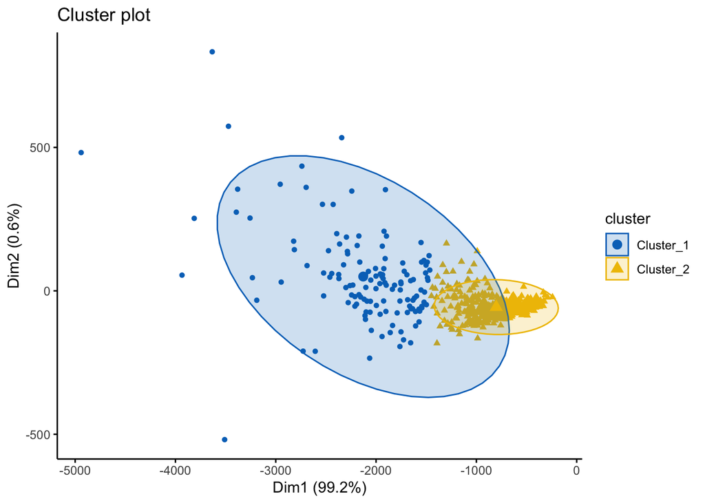

```r
kmeans_spec <- k_means(num_clusters = 2) |>
  set_mode("partition") |>
  set_engine("stats") |>
  set_args(nstart = 20)


kmeans_fit <- kmeans_spec |>
  fit(~., data = wisc_pred)

wisc_km <- augment(kmeans_fit, new_data = wisc_pred)

fviz_cluster(list(data = wisc_pred, cluster = wisc_km$.pred_cluster),
ellipse.type = "norm", geom = "point", stand = FALSE, palette = "jco", ggtheme = theme_classic())
```

```r
table(wisc_diag$Diagnosis, wisc_km$.pred_cluster)
```

```
    Cluster_1 Cluster_2
  B         1       356
  M       130        82
```

2. Perform k-means clustering with k=2 on this data set using only the first few PCs from PCA (you can do this by creating a recipe with `step_pca`) on the **unscaled** data. Make a plot of all the data points colored by their assigned cluster label. Print out a confusion matrix of the assigned cluster labels with the Diagnosis value for all the points and report the number of points assigned to the “wrong” cluster (since cluster labels are arbitrary, either cluster 1 or 2 may correspond to Diagnosis ‘M’ or ‘B’).

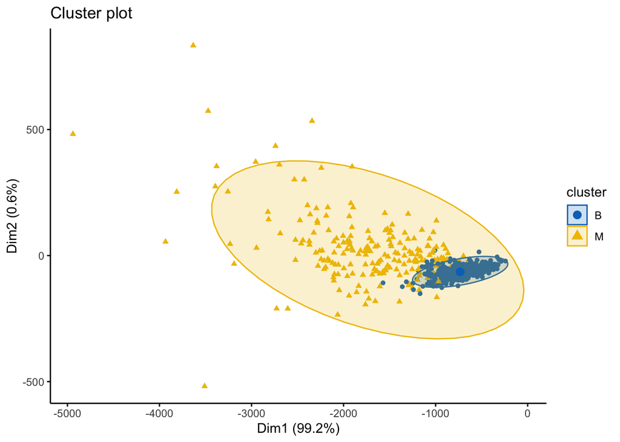

```r
kmeans_rec <- recipe(~., data = wisc_pred) |>
  #step_normalize(all_numeric()) |>
  step_pca(all_numeric(), num_comp = 2) #|>
#  prep() |>
 # bake(new_data = NULL)

workflow_km <- workflow() |>
  add_model(kmeans_spec) |>
  add_recipe(kmeans_rec)

kmeans_fit <-  workflow_km |>
  fit(wisc_pred)

wisc_km <- augment(kmeans_fit, new_data = wisc_pred)

fviz_cluster(list(data = wisc_pred, cluster = wisc_diag$Diagnosis),
ellipse.type = "norm", geom = "point", stand = FALSE, palette = "jco", ggtheme = theme_classic())
```

```r
table(wisc_diag$Diagnosis, wisc_km$.pred_cluster)
```

```
    Cluster_1 Cluster_2
  B         1       356
  M       130        82
```

4. Perform k-means clustering with k=2 on this data set using only the first few PCs from PCA (you can do this by creating a recipe with `step_pca`) on the **scaled** data. Make a plot of all the data points colored by their assigned cluster label. Print out a confusion matrix of the assigned cluster labels with the Diagnosis value for all the points and report the number of points assigned to the “wrong” cluster (since cluster labels are arbitrary, either cluster 1 or 2 may correspond to Diagnosis ‘M’ or ‘B’).

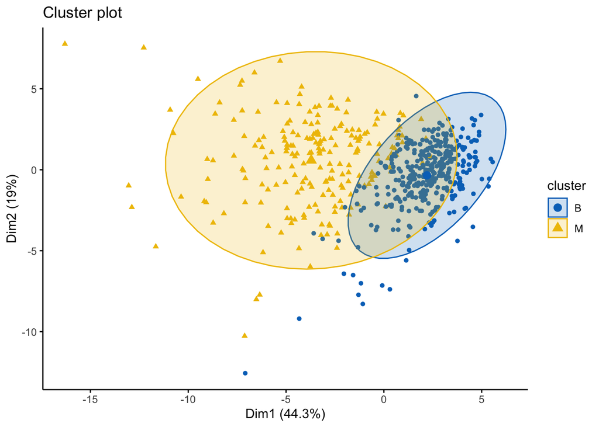

   ```r
   kmeans_rec <- recipe(~., data = wisc_pred) |>
     step_normalize(all_numeric()) |>
     step_pca(all_numeric(), threshold = 0.7) #|>
   #  prep() |>
    # bake(new_data = NULL)

   workflow_km <- workflow() |>
     add_model(kmeans_spec) |>
     add_recipe(kmeans_rec)

   kmeans_fit <-  workflow_km |>
     fit(wisc_pred)

   wisc_km <- augment(kmeans_fit, new_data = wisc_pred)

   fviz_cluster(list(data = scale(wisc_pred), cluster = wisc_diag$Diagnosis),
   ellipse.type = "norm", geom = "point", stand = FALSE, palette = "jco", ggtheme = theme_classic())
   ```

   ```r
   table(wisc_diag$Diagnosis, wisc_km$.pred_cluster)
   ```

   ```
       Cluster_1 Cluster_2
     B        14       343
     M       175        37
   ```

5. Choose either the complete set of variables or the reduced set of principal components, and perform hyperparameter tuning to find the optimal value of k in k-means using `tidymodels` tools. Make a plot of within SSE (sum of squared errors within clusters) as a function of k (try values between 1 and 10) and use the elbow method to determine the optimal value of k.

```r
kmeans_spec_tuned <- kmeans_spec |>
  set_args(num_clusters = tune())


pca_recipe <-
  recipe(formula =  ~ ., data = wisc_pred) |>
  step_novel(all_nominal_predictors()) |>
  step_dummy(all_nominal_predictors()) |>
  step_zv(all_predictors()) |>
  step_normalize(all_predictors()) |>
  step_pca(all_predictors(), threshold = 0.8)

kmeans_wf <- workflow() |>
  add_model(kmeans_spec_tuned) |>
  add_recipe(pca_recipe)

splits <- bootstraps(wisc_pred, times = 10)

num_clusters_grid <- tibble(num_clusters = seq(1, 10))

tune_res <- tune_cluster(
  object = kmeans_wf,
  resamples = splits,
  grid = num_clusters_grid
)
```

```
! Bootstrap06: preprocessor 1/1, model 8/10: did not converge in 10 iterations
```

```r
tune_res |>
  collect_metrics()
```

```
# A tibble: 20 × 7
   num_clusters .metric          .estimator   mean     n std_err .config
          <int> <chr>            <chr>       <dbl> <int>   <dbl> <chr>
 1            1 sse_total        standard   14232.    10    119. Preprocessor1_…
 2            1 sse_within_total standard   14232.    10    119. Preprocessor1_…
 3            2 sse_total        standard   14232.    10    119. Preprocessor1_…
 4            2 sse_within_total standard    8759.    10    176. Preprocessor1_…
 5            3 sse_total        standard   14232.    10    119. Preprocessor1_…
 6            3 sse_within_total standard    7190.    10    167. Preprocessor1_…
 7            4 sse_total        standard   14232.    10    119. Preprocessor1_…
 8            4 sse_within_total standard    6344.    10    168. Preprocessor1_…
 9            5 sse_total        standard   14232.    10    119. Preprocessor1_…
10            5 sse_within_total standard    5661.    10    159. Preprocessor1_…
11            6 sse_total        standard   14232.    10    119. Preprocessor1_…
12            6 sse_within_total standard    5133.    10    152. Preprocessor1_…
13            7 sse_total        standard   14232.    10    119. Preprocessor1_…
14            7 sse_within_total standard    4684.    10    143. Preprocessor1_…
15            8 sse_total        standard   14232.    10    119. Preprocessor1_…
16            8 sse_within_total standard    4318.    10    134. Preprocessor1_…
17            9 sse_total        standard   14232.    10    119. Preprocessor1_…
18            9 sse_within_total standard    4031.    10    130. Preprocessor1_…
19           10 sse_total        standard   14232.    10    119. Preprocessor1_…
20           10 sse_within_total standard    3817.    10    125. Preprocessor1_…
```

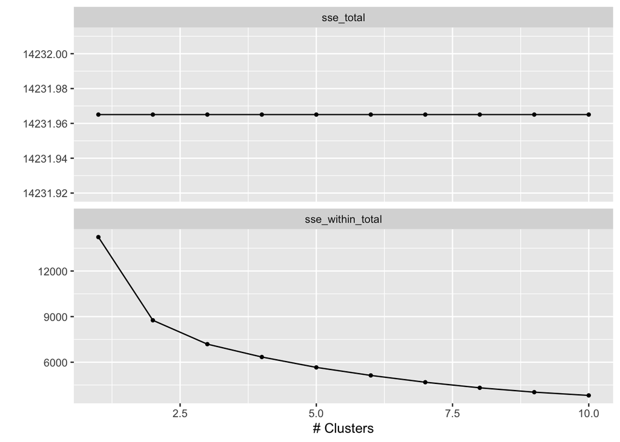

```r
tune_res |>
  autoplot()
```

6. Compare the performance of clustering with and without reducing dimensionality, in terms of its agreement with the true labels (from Diagnosis). Explain the meaning of the elbow method for hyperparameter tuning and whether the result is surprising.

## Liver injury data

7. Perform k-means clustering with k=3 on the liver injury data set using all the scaled variables. Make a plot of all the data points colored by their assigned cluster label. Print out a confusion matrix of the assigned cluster labels with the `class` value for all the points.

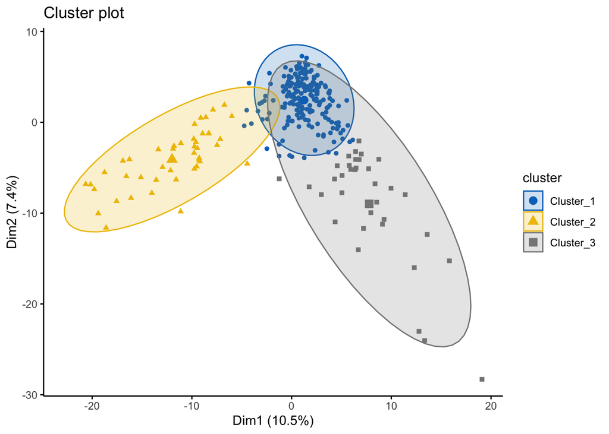

```r
kmeans_spec <- k_means(num_clusters = 3) |>
  set_mode("partition") |>
  set_engine("stats") |>
  set_args(nstart = 20)


liver_rec <- liver_clean |>
  recipe(formula =  ~ .) |>
  step_novel(all_nominal_predictors()) |>
  step_dummy(all_nominal_predictors()) |>
  step_zv(all_predictors()) |>
  step_normalize(all_predictors())

kmeans_wf <- workflow() |>
  add_model(kmeans_spec) |>
  add_recipe(liver_rec)

kmeans_fit <- kmeans_wf  |>
  fit(liver_clean)

liver_km <- predict(kmeans_fit, new_data = liver_clean)

fviz_cluster(list(data = scale(liver_clean), cluster = liver_km$.pred_cluster),
ellipse.type = "norm", geom = "point", stand = FALSE, palette = "jco", ggtheme = theme_classic())
```

```r
table(liver_km$.pred_cluster, liver_class$class)
```

```
            none mild severe
  Cluster_1   68  115     19
  Cluster_2   24   17      3
  Cluster_3   14   13      8
```

8. Perform k-means clustering with k=3 on the liver injury data set using the scaled and PCA-reduced dimensions (use the function `step_pca()` with the option `threshold` to specify the fraction of variance you want retain in the reduced dimensions. Make a plot of all the data points colored by their assigned cluster label. Print out a confusion matrix of the assigned cluster labels with the `class` value for all the points.

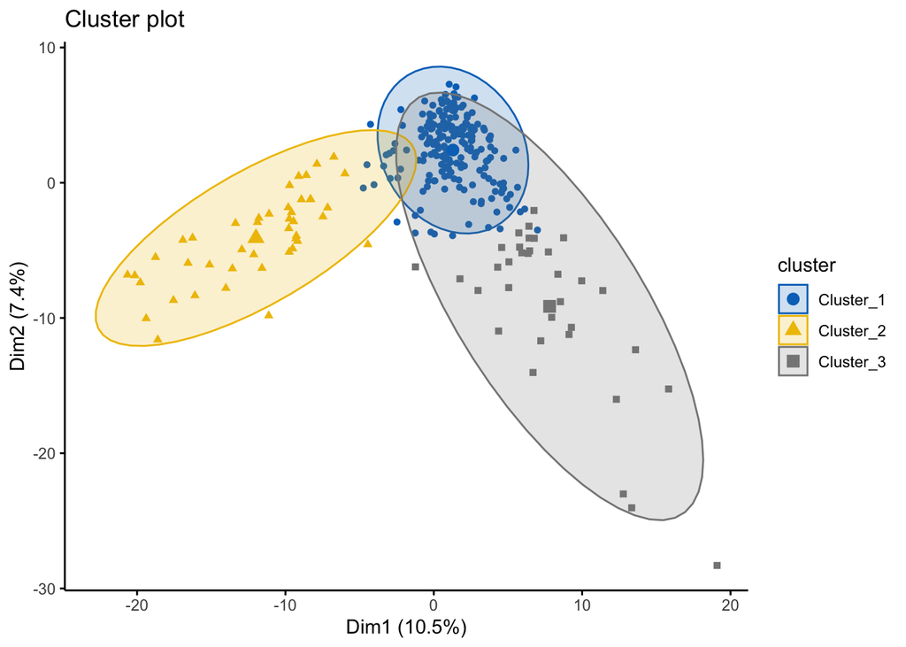

```r
liver_rec <- liver_clean |>
  recipe(formula =  ~ .) |>
  step_novel(all_nominal_predictors()) |>
  step_dummy(all_nominal_predictors()) |>
  step_zv(all_predictors()) |>
  step_normalize(all_predictors()) |>
  step_pca(all_predictors(), threshold = 0.7)

kmeans_wf <- workflow() |>
  add_model(kmeans_spec) |>
  add_recipe(liver_rec)

kmeans_fit <- kmeans_wf  |>
  fit(liver_clean)

liver_km <- predict(kmeans_fit, new_data = liver_clean)

fviz_cluster(list(data = scale(liver_clean), cluster = liver_km$.pred_cluster),
ellipse.type = "norm", geom = "point", stand = FALSE, palette = "jco", ggtheme = theme_classic())
```

```r
table(liver_km$.pred_cluster, liver_class$class)
```

```
            none mild severe
  Cluster_1   68  116     19
  Cluster_2   24   17      3
  Cluster_3   14   12      8
```

9. Use the reduced set of principal components and perform hyperparameter tuning to find the optimal value of k in k-means using `tidymodels` tools. Make a plot of within SSE (sum of squared errors within clusters) as a function of k (try values between 1 and 10) and use the elbow method to determine the optimal value of k.

   ```r
   kmeans_spec_tuned <- kmeans_spec |>
     set_args(num_clusters = tune())


   pca_recipe <-
     recipe(formula =  ~ ., data = liver_clean) |>
     step_novel(all_nominal_predictors()) |>
     step_dummy(all_nominal_predictors()) |>
     step_zv(all_predictors()) |>
     step_normalize(all_predictors()) |>
     step_pca(all_predictors(), threshold = 0.7)

   kmeans_wf <- workflow() |>
     add_model(kmeans_spec_tuned) |>
     add_recipe(pca_recipe)

   splits <- bootstraps(liver_clean, times = 10)

   num_clusters_grid <- tibble(num_clusters = seq(1, 10))

   tune_res <- tune_cluster(
     object = kmeans_wf,
     resamples = splits,
     grid = num_clusters_grid
   )

   tune_res |>
     collect_metrics()
   ```

   ```
   # A tibble: 20 × 7
      num_clusters .metric          .estimator   mean     n std_err .config
             <int> <chr>            <chr>       <dbl> <int>   <dbl> <chr>
    1            1 sse_total        standard   71855.    10    145. Preprocessor1_…
    2            1 sse_within_total standard   71855.    10    145. Preprocessor1_…
    3            2 sse_total        standard   71855.    10    145. Preprocessor1_…
    4            2 sse_within_total standard   63050.    10    198. Preprocessor1_…
    5            3 sse_total        standard   71855.    10    145. Preprocessor1_…
    6            3 sse_within_total standard   57203.    10    136. Preprocessor1_…
    7            4 sse_total        standard   71855.    10    145. Preprocessor1_…
    8            4 sse_within_total standard   53834.    10    252. Preprocessor1_…
    9            5 sse_total        standard   71855.    10    145. Preprocessor1_…
   10            5 sse_within_total standard   51361.    10    294. Preprocessor1_…
   11            6 sse_total        standard   71855.    10    145. Preprocessor1_…
   12            6 sse_within_total standard   49156.    10    290. Preprocessor1_…
   13            7 sse_total        standard   71855.    10    145. Preprocessor1_…
   14            7 sse_within_total standard   47077.    10    420. Preprocessor1_…
   15            8 sse_total        standard   71855.    10    145. Preprocessor1_…
   16            8 sse_within_total standard   45272.    10    355. Preprocessor1_…
   17            9 sse_total        standard   71855.    10    145. Preprocessor1_…
   18            9 sse_within_total standard   43257.    10    429. Preprocessor1_…
   19           10 sse_total        standard   71855.    10    145. Preprocessor1_…
   20           10 sse_within_total standard   41585.    10    367. Preprocessor1_…
   ```

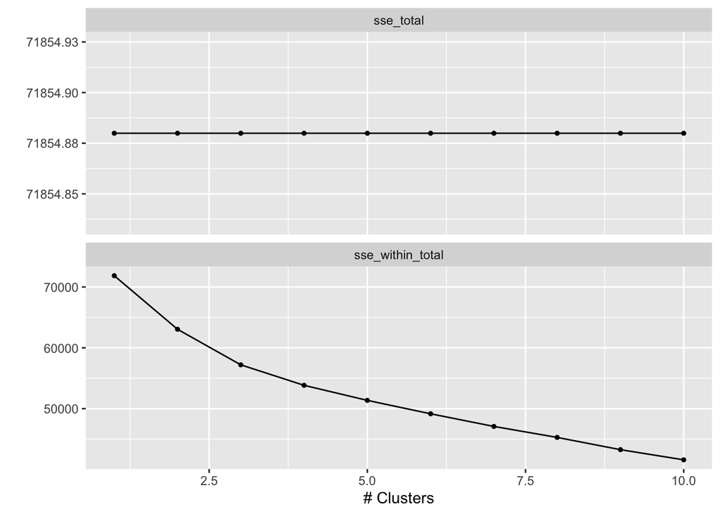

   ```r
   tune_res |>
     autoplot()
   ```

10. Perform hierarchical clustering on the same data set using the method “single” using the scaled and PCA-reduced dimensions (use the function `step_pca()` with the option `threshold` to specify the fraction of variance you want retain in the reduced dimensions. Make a plot of all the data points colored by their assigned cluster label. Print out a confusion matrix of the assigned cluster labels with the `class` value for all the points.

```
Too few points to calculate an ellipse
Too few points to calculate an ellipse
```

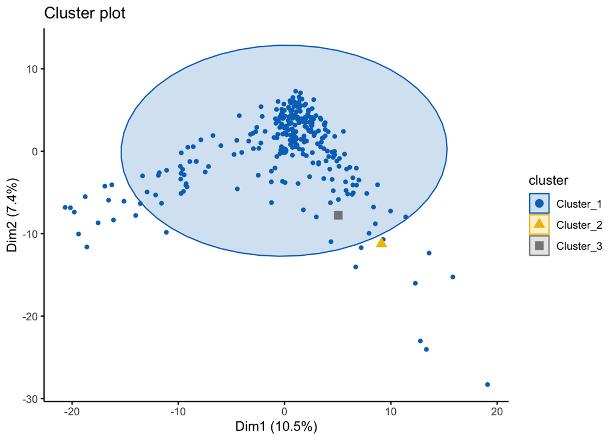

```r
hclust_spec <- hier_clust(linkage_method = "single")

hclust_wf <- workflow() |>
  add_model(hclust_spec) |>
  add_recipe(liver_rec)

hclust_fit <- hclust_wf  |>
  fit(liver_clean)

liver_hc <- predict(hclust_fit, new_data = liver_clean, num_clusters = 3)

fviz_cluster(list(data = scale(liver_clean), cluster = liver_hc$.pred_cluster),
ellipse.type = "norm", geom = "point", stand = FALSE, palette = "jco", ggtheme = theme_classic())
```

```r
print("The confusion matrix for hierarchical clustering using single linkage method:")
```

```
[1] "The confusion matrix for hierarchical clustering using single linkage method:"
```

```r
table(liver_hc$.pred_cluster, liver_class$class)
```

```
            none mild severe
  Cluster_1  105  144     30
  Cluster_2    1    0      0
  Cluster_3    0    1      0
```

11. Try using other linkage methods (e.g. “complete” and “average”) and report the same confusion matrix for both.

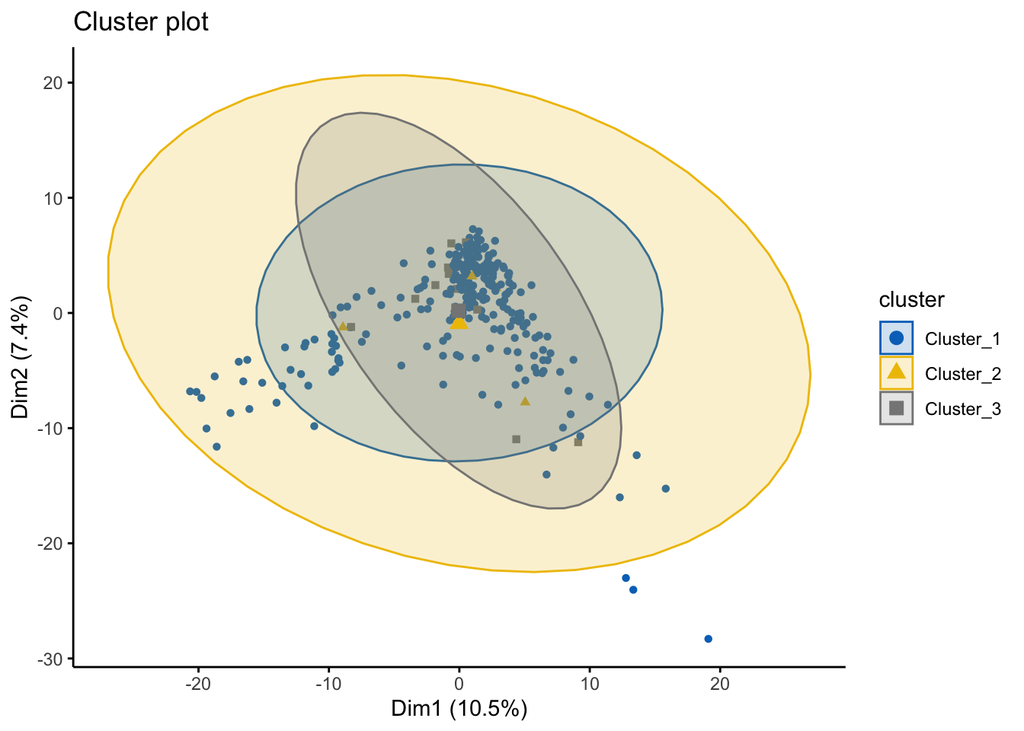

```r
hclust_spec <- hier_clust(linkage_method = "complete")

hclust_wf <- workflow() |>
  add_model(hclust_spec) |>
  add_recipe(liver_rec)

hclust_fit <- hclust_wf  |>
  fit(liver_clean)

liver_hc <- predict(hclust_fit, new_data = liver_clean, num_clusters = 3)

fviz_cluster(list(data = scale(liver_clean), cluster = liver_hc$.pred_cluster),
ellipse.type = "norm", geom = "point", stand = FALSE, palette = "jco", ggtheme = theme_classic())
```

```r
print("The confusion matrix for hierarchical clustering using complete linkage method:")
```

```
[1] "The confusion matrix for hierarchical clustering using complete linkage method:"
```

```r
table(liver_hc$.pred_cluster, liver_class$class)
```

```
            none mild severe
  Cluster_1   98  138     30
  Cluster_2    2    2      0
  Cluster_3    6    5      0
```

```
Too few points to calculate an ellipse
Too few points to calculate an ellipse
```

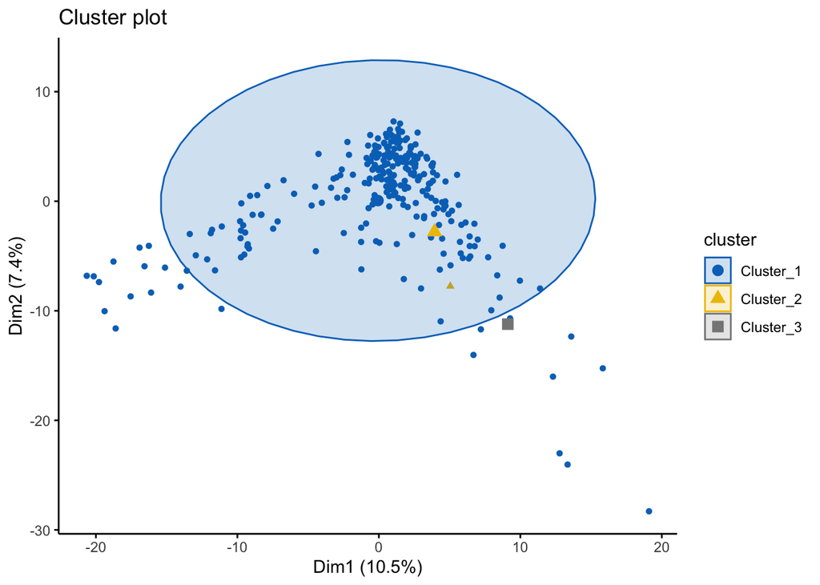

```r
hclust_spec <- hier_clust(linkage_method = "average")

hclust_wf <- workflow() |>
  add_model(hclust_spec) |>
  add_recipe(liver_rec)

hclust_fit <- hclust_wf  |>
  fit(liver_clean)

liver_hc <- predict(hclust_fit, new_data = liver_clean, num_clusters = 3)

fviz_cluster(list(data = scale(liver_clean), cluster = liver_hc$.pred_cluster),
ellipse.type = "norm", geom = "point", stand = FALSE, palette = "jco", ggtheme = theme_classic())
```

```r
print("The confusion matrix for hierarchical clustering using average linkage method:")
```

```
[1] "The confusion matrix for hierarchical clustering using average linkage method:"
```

```r
table(liver_hc$.pred_cluster, liver_class$class)
```

```
            none mild severe
  Cluster_1  104  144     30
  Cluster_2    1    1      0
  Cluster_3    1    0      0
```

12. Report how the clustering quality (as judged by comparison with the true value of `class`) depends on the type of clustering algorithm.

    This is a very tough data set to cluster, and hierarchical methods fail completely; the k-means does only about as good as a coin toss.